# Tracking comorbidity between depression and substance abuse over the past ten years

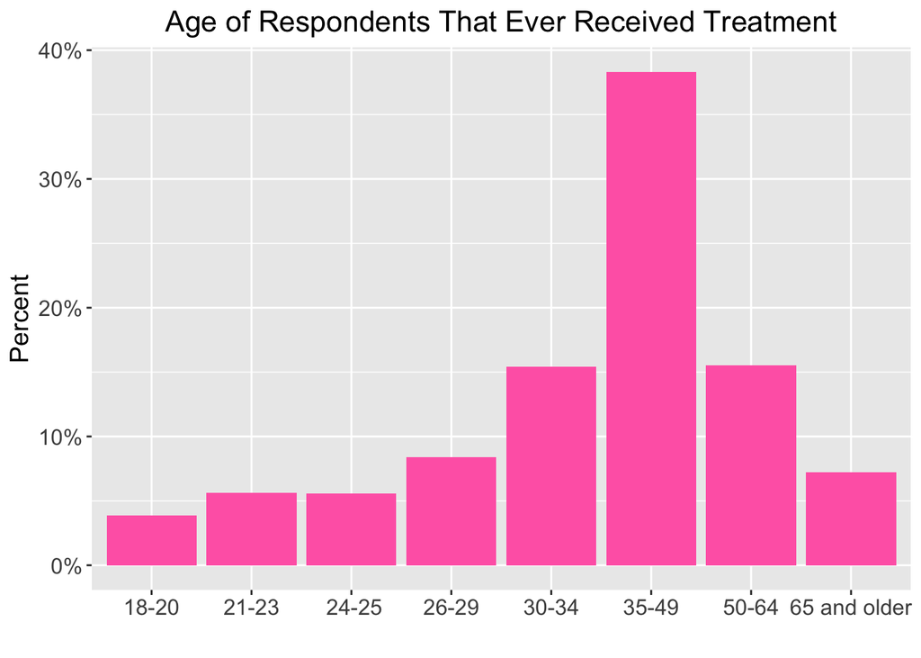

```r
 #age of respondents who have received treatment
 clean_NSDUH %>%
   filter(rec_sub_trtm == "yes") %>%
   filter(!is.na(age)) %>%
   ggplot(aes(x = age, y = after_stat(count/sum(count)))) +
   geom_bar(fill = "hotpink") +
   plot_theme() +
   scale_y_continuous(labels = percent) +
   ggtitle("Age of Respondents That Ever Received Treatment") +
   xlab(" ") +
   ylab("Percent")
```

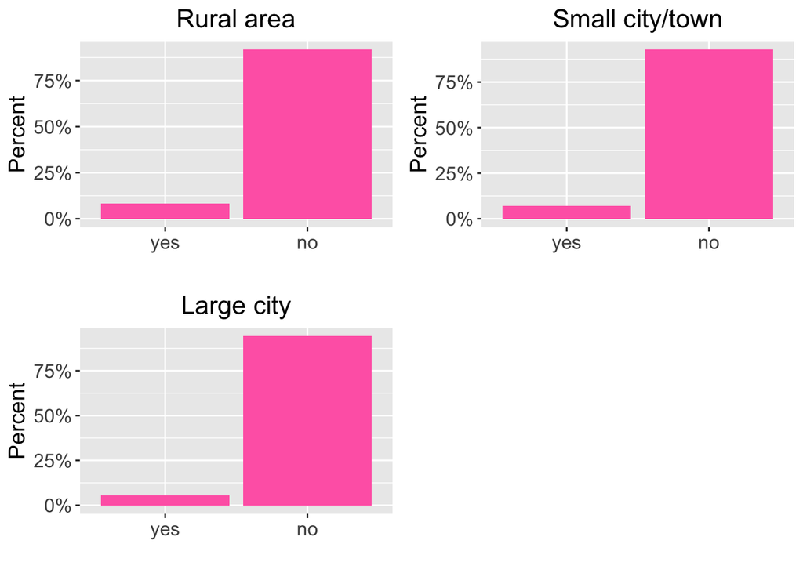

```r
 #Respondents from rural areas
 rural <- clean_NSDUH %>%
    filter(!is.na(rec_sub_trtm)) %>%
    filter(citysize == "Rural") %>%
    ggplot(aes(x = rec_sub_trtm, y = after_stat(count/sum(count)))) +
    geom_bar(fill = "hotpink") +
    plot_theme() +
    scale_y_continuous(labels = percent) +
    ggtitle("Rural area") +
    xlab(" ") +
    ylab("Percent")

 smallcity <- clean_NSDUH %>%
   filter(!is.na(rec_sub_trtm)) %>%
   filter(citysize == "small city/town") %>%
   ggplot(aes(x = rec_sub_trtm, y = after_stat(count/sum(count)))) +
   geom_bar(fill = "hotpink") +
   plot_theme() +
   scale_y_continuous(labels = percent) +
   ggtitle("Small city/town") +
   xlab(" ") +
   ylab("Percent")



  #respondents from large cities
  largecity <- clean_NSDUH %>%
    filter(!is.na(rec_sub_trtm)) %>%
    filter(citysize == "large city") %>%
    ggplot(aes(x = rec_sub_trtm, y = after_stat(count/sum(count)))) +
    geom_bar(fill = "hotpink") +
    plot_theme() +
    scale_y_continuous(labels = percent) +
    ggtitle("Large city") +
    xlab(" ") +
    ylab("Percent")

grid.arrange(rural,smallcity,largecity, nrow = 2)
```

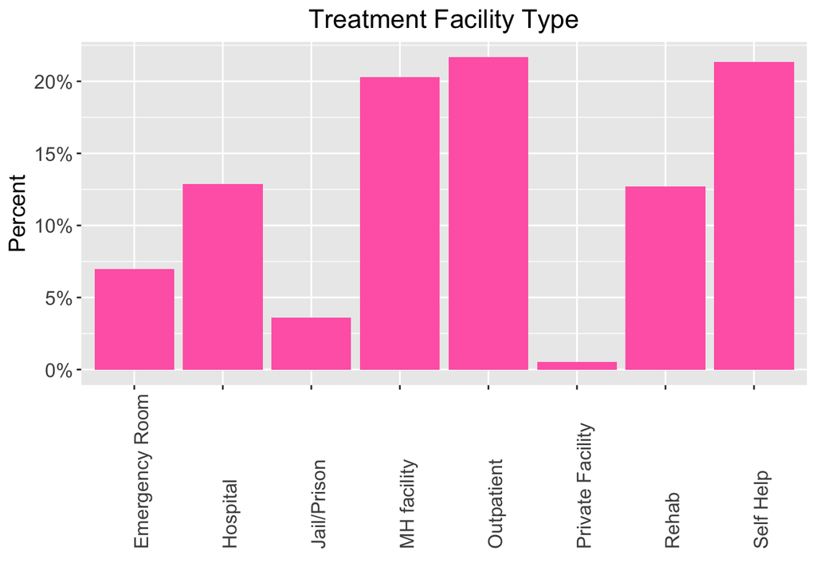

```r
 #compare where respondents received treatment
  NSDUH_long <- clean_NSDUH %>%
    rename(Hospital = hos_trtm, Rehab = rehab_trtm,
            Outpatient = outpatient_trtm, "MH facility" = mhfacility_trtm, "Emergency Room" = ER_trtm,
            "Private Facility" = private_trtm, "Jail/Prison" = prison_trtm, "Self Help" =selfhelp_trtm)

  NSDUH_long <- gather(NSDUH_long, key = "Facility", value="response", c("Hospital", "Rehab",
                                                                          "Outpatient", "MH facility", "Emergency Room",
                                                                          "Private Facility", "Jail/Prison", "Self Help"))

  NSDUH_long %>%
  filter(rec_sub_trtm == "yes") %>%
  filter(response == "yes")%>%
    ggplot(aes(x = Facility, y = after_stat(count/sum(count)), fill = response)) +
    geom_bar(fill = "hotpink", position = 'dodge') +
    plot_theme() +
    scale_y_continuous(labels = percent) +
    ggtitle("Treatment Facility Type") +
    xlab(" ") +
    ylab("Percent") +
    easy_rotate_x_labels(angle = 90)
```

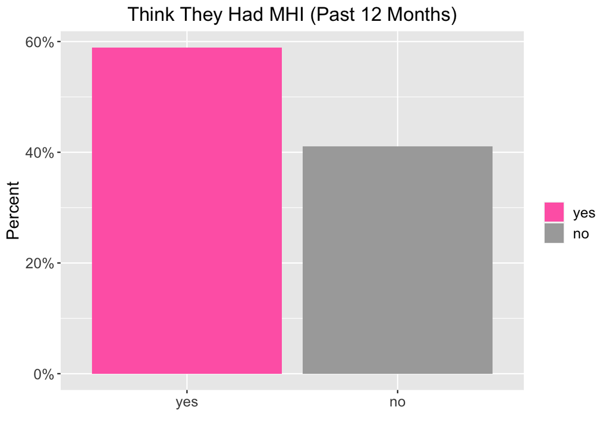

```r
    #Respondents who received treatment and think they had MH issues
  clean_NSDUH %>%
    filter(rec_sub_trtm == "yes") %>%
    filter(!is.na(think_had_mh)) %>%
    ggplot(aes(x = think_had_mh, y = after_stat(count/sum(count)), fill = think_had_mh)) +
    geom_bar() +
    plot_theme() +
    scale_y_continuous(labels = percent) +
    ggtitle("Think They Had MHI (Past 12 Months)") +
    xlab(" ") +
    ylab("Percent") +
    scale_fill_manual(name=" ",values=c("hotpink","darkgrey"))
```

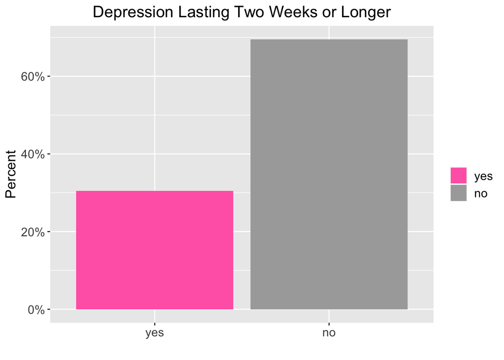

```r
#Respondents who had depression lasting two weeks or longer
  clean_NSDUH %>%
    filter(rec_sub_trtm == "yes") %>%
    filter(!is.na(dep_two_weeks)) %>%
    ggplot(aes(x = dep_two_weeks, y = after_stat(count/sum(count)), fill = dep_two_weeks)) +
    geom_bar() +
    plot_theme() +
    scale_y_continuous(labels = percent) +
    ggtitle("Depression Lasting Two Weeks or Longer") +
    xlab(" ") +
    ylab("Percent") +
    scale_fill_manual(name=" ",values=c("hotpink","darkgrey"))
```

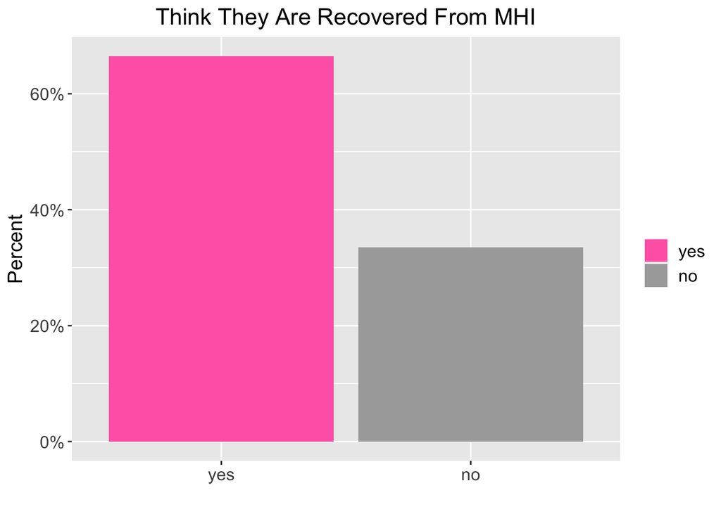

```r
 #Respondents who believe they had MHI who think they are recovered
  clean_NSDUH %>%
    filter(rec_sub_trtm == "yes" & think_had_mh == "yes") %>%
    filter(!is.na(think_recovered_mh)) %>%
    ggplot(aes(x = think_recovered_mh, y = after_stat(count/sum(count)), fill = think_recovered_mh)) +
    geom_bar() +
    plot_theme() +
    scale_y_continuous(labels = percent) +
    ggtitle("Think They Are Recovered From MHI") +
    xlab(" ") +
    ylab("Percent") +
    scale_fill_manual(name=" ",values=c("hotpink","darkgrey"))
```

**Histogram**

A histogram was used to analyze the number of weeks that respondents had MHI.

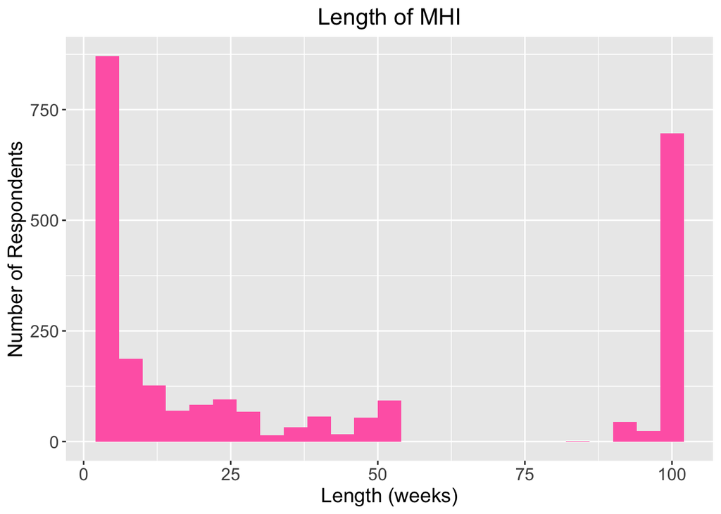

```r
    #number of weeks of MHI
  clean_NSDUH %>%
    filter(rec_sub_trtm == "yes") %>%
    filter(num_weeks_mh >= 2) %>%
    ggplot(aes(x = num_weeks_mh)) +
    geom_histogram(fill = "hotpink", binwidth = 4) +
    plot_theme() +
    ggtitle("Length of MHI") +
    xlab("Length (weeks)") +
    ylab("Number of Respondents")
```

## 4 Results

**Almost half of respondents who ever received SUD treatment received it in the past 12 months**

The first area to be explored was how many respondents have received SUD treatment at any point in their life. Majority of respondents have not received SUD treatment, with about six percent of respondents claiming they have received SUD treatment at one point in their life. From the six percent that have received treatment further analysis was done to determine who has received treatment in the past 12 months. It was found that about 45 percent of these respondents received treatment in the past year. However, it should be noted that the survey does not clarify of this 45 percent how many received SUD treatment for the first time in the past year versus respondents who have received previous treatment prior to this year, so these data should not be used to determine if SUD treatment rates have increased in the past 12 months.

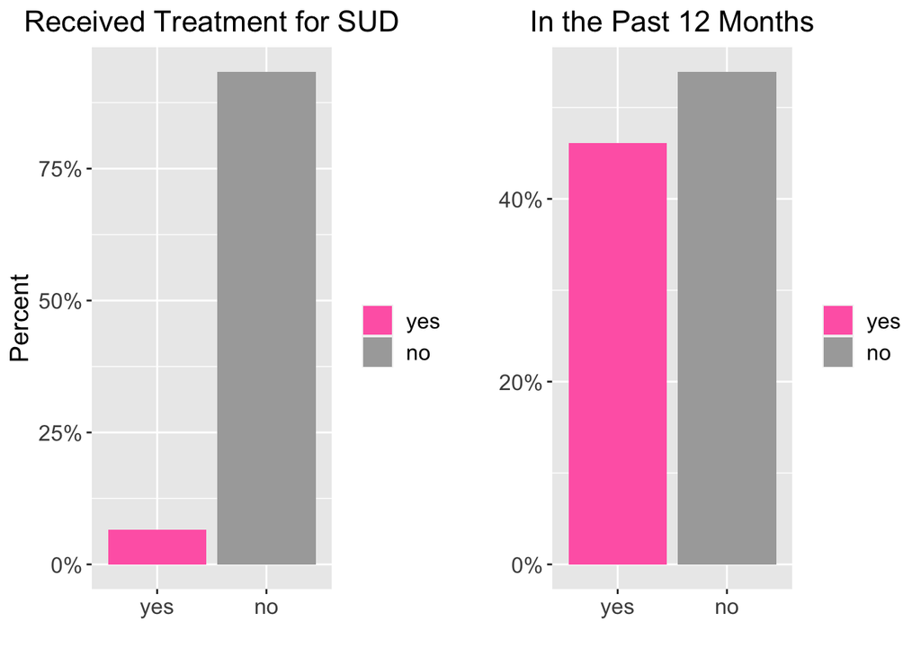

```r
 plot_theme <- function() {
   theme(plot.title=element_text(hjust=0.5,size=16),axis.text.y = element_text(size=12),axis.text.x = element_text(size=12),
         axis.title.y = element_text(size=14),axis.title.x = element_text(size=14),
         legend.text = element_text(size = 12),legend.title = element_text(size = 14))
 }


 # Show bar plot of respondents who ever required substance use treatment
 ever <- clean_NSDUH %>%
   filter(!is.na(rec_sub_trtm)) %>%
   ggplot(aes(x = rec_sub_trtm, y = after_stat(count/sum(count)), fill = rec_sub_trtm)) +
   geom_bar() +
   plot_theme() +
   scale_y_continuous(labels = percent) +
   ggtitle("Received Treatment for SUD") +
   xlab(" ") +
   ylab("Percent") +
   scale_fill_manual(name=" ",values=c("hotpink","darkgrey"))

 # Show bar plot of respondents who required substance use treatment in the past year
 pastyear <- clean_NSDUH %>%
   filter(!is.na(sub_trtm_12mo)) %>%
   ggplot(aes(x = sub_trtm_12mo, y = after_stat(count/sum(count)), fill = sub_trtm_12mo)) +
   geom_bar() +
   plot_theme() +
   scale_y_continuous(labels = percent) +
   ggtitle("In the Past 12 Months") +
   xlab(" ") +
   ylab(" ") +
   scale_fill_manual(name=" ",values=c("hotpink","darkgrey"))

   grid.arrange(ever, pastyear, nrow = 1)
```

**Middle age was the largest group to receive SUD treatment**

Next the general age of respondents who have ever received treatment in their life was analyzed. It was found that close to forty percent of those who received treatment were between the ages of 35-49. With 30-34 year olds and 50-64 year olds as the second most frequent age groups to receive treatment. One thing to take into account, is that these ages on the survey appear to be grouped based on stage of life rather than consistent increments. For example, 35-49 years old is a much broader age range than 24-25 years old that is also one of the selections on the survey. However, higher rates of middle aged adults receiving treatment may not be surprising due to the stage of life people are often in where SUD can begin to have dire consequences on health, careers and family life therefore creating more pressure to seek help.

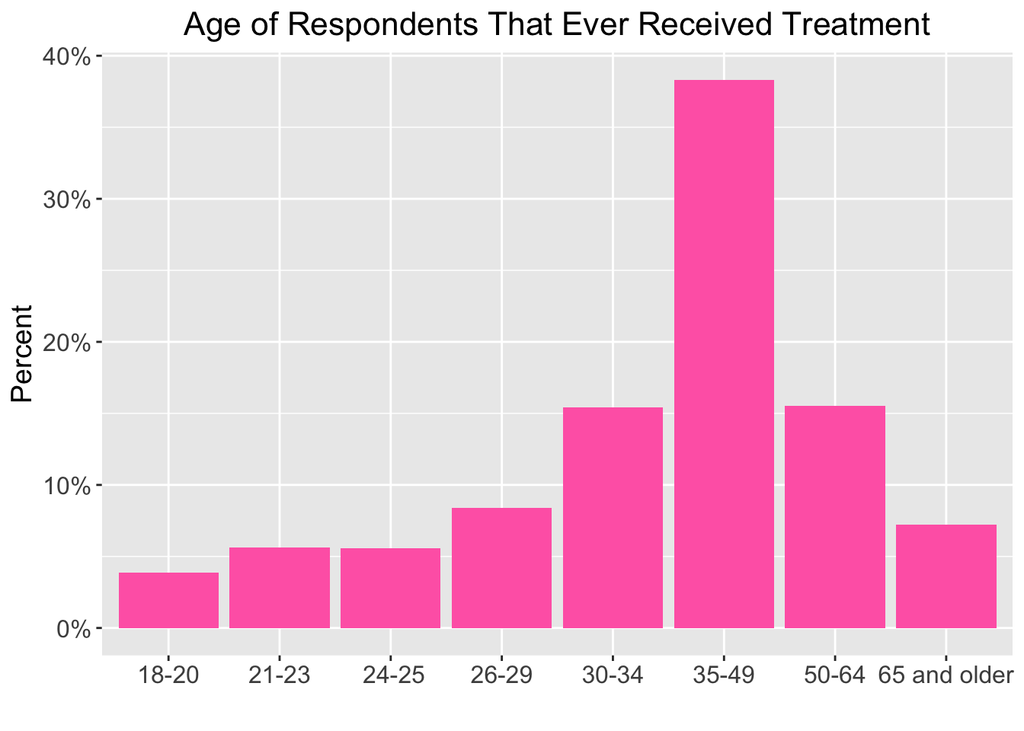

```r
#age of respondents who have received treatment
 clean_NSDUH %>%
   filter(rec_sub_trtm == "yes") %>%
   filter(!is.na(age)) %>%
   ggplot(aes(x = age, y = after_stat(count/sum(count)))) +
   geom_bar(fill = "hotpink") +
   plot_theme() +
   scale_y_continuous(labels = percent) +
   ggtitle("Age of Respondents That Ever Received Treatment") +
   xlab(" ") +
   ylab("Percent")
```

**No difference in SUD treatment rates were found in more populated vs. rural areas**

Specific locations of the respondents was not recorded in the survey due to privacy reasons but they did include a question on the size of town or city that they resided in. There was no difference in SUD treatment rates found between respondents in rural areas, small cities or large cities.

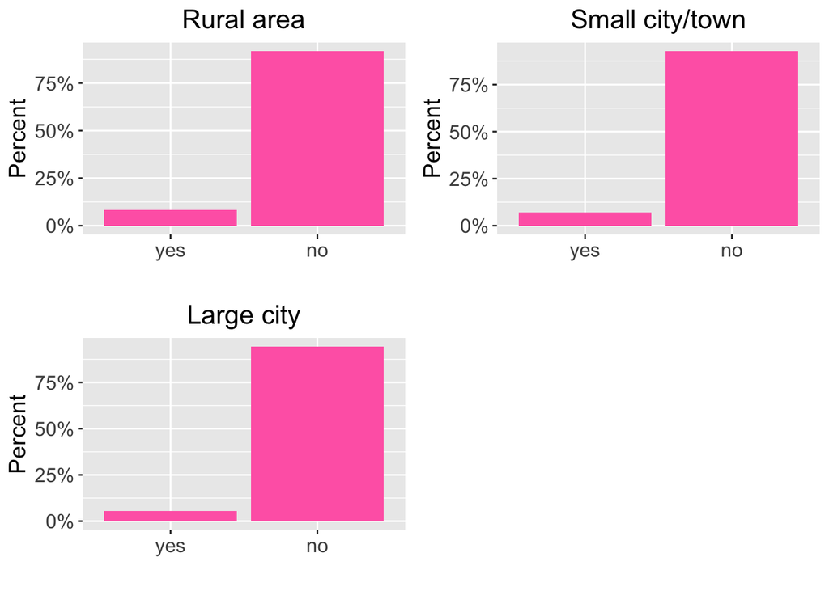

```r
 #Respondents from rural areas
 rural <- clean_NSDUH %>%
    filter(!is.na(rec_sub_trtm)) %>%
    filter(citysize == "Rural") %>%
    ggplot(aes(x = rec_sub_trtm, y = after_stat(count/sum(count)))) +
    geom_bar(fill = "hotpink") +
    plot_theme() +
    scale_y_continuous(labels = percent) +
    ggtitle("Rural area") +
    xlab(" ") +
    ylab("Percent")

 smallcity <- clean_NSDUH %>%
   filter(!is.na(rec_sub_trtm)) %>%
   filter(citysize == "small city/town") %>%
   ggplot(aes(x = rec_sub_trtm, y = after_stat(count/sum(count)))) +
   geom_bar(fill = "hotpink") +
   plot_theme() +
   scale_y_continuous(labels = percent) +
   ggtitle("Small city/town") +
   xlab(" ") +
   ylab("Percent")



  #respondents from large cities
  largecity <- clean_NSDUH %>%
    filter(!is.na(rec_sub_trtm)) %>%
    filter(citysize == "large city") %>%
    ggplot(aes(x = rec_sub_trtm, y = after_stat(count/sum(count)))) +
    geom_bar(fill = "hotpink") +
    plot_theme() +
    scale_y_continuous(labels = percent) +
    ggtitle("Large city") +
    xlab(" ") +
    ylab("Percent")

grid.arrange(rural,smallcity,largecity, nrow = 2)
```

**Mental health facilities, self-help and outpatient programs ranked highest in type of SUD treatment**

The location of where treatment was received was looked into. The highest rates of SUD treatment were received at mental health(MH) facilities, self-help and outpatient programs. The lowest number of respondents received treatment at private facilities such as a primary care doctor. This may be due to cost or lack of health insurance that is required to have a primary care doctor while the other locations either free, low cost or provide options for those who are insured.

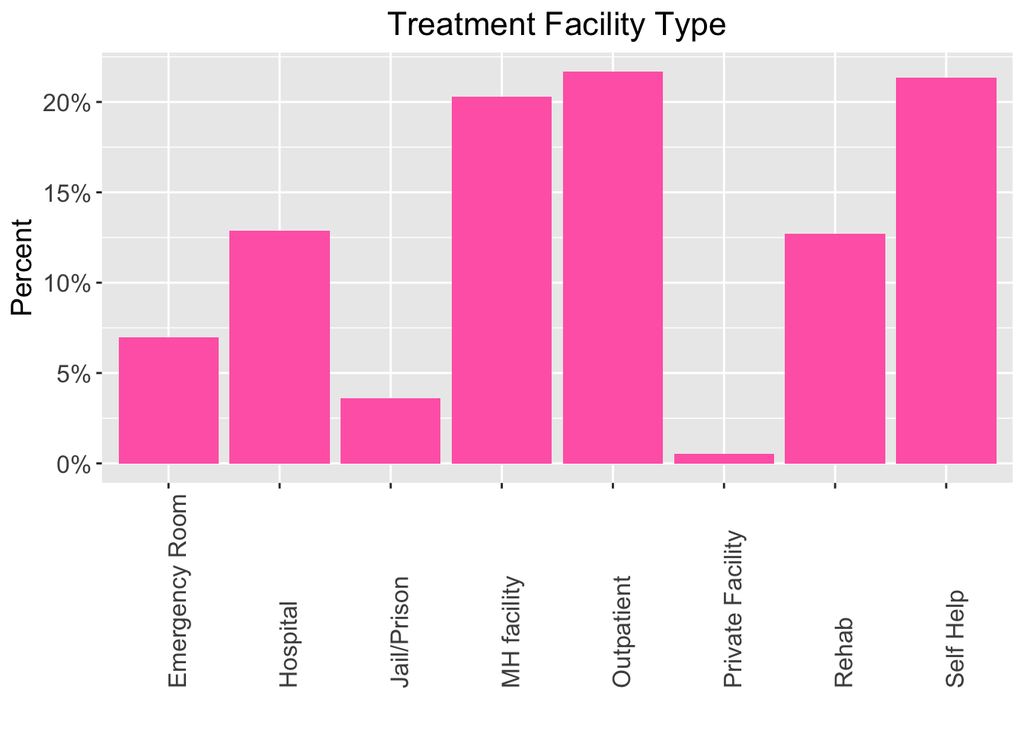

```r
 #compare where respondents received treatment
  NSDUH_long <- clean_NSDUH %>%
    rename(Hospital = hos_trtm, Rehab = rehab_trtm,
            Outpatient = outpatient_trtm, "MH facility" = mhfacility_trtm, "Emergency Room" = ER_trtm,
            "Private Facility" = private_trtm, "Jail/Prison" = prison_trtm, "Self Help" =selfhelp_trtm)

  NSDUH_long <- gather(NSDUH_long, key = "Facility", value="response", c("Hospital", "Rehab",
                                                                          "Outpatient", "MH facility", "Emergency Room",
                                                                          "Private Facility", "Jail/Prison", "Self Help"))

  NSDUH_long %>%
  filter(rec_sub_trtm == "yes") %>%
  filter(response == "yes")%>%
    ggplot(aes(x = Facility, y = after_stat(count/sum(count)), fill = response)) +
    geom_bar(fill = "hotpink", position = 'dodge') +
    plot_theme() +
    scale_y_continuous(labels = percent) +
    ggtitle("Treatment Facility Type") +
    xlab(" ") +
    ylab("Percent") +
    easy_rotate_x_labels(angle = 90)
```

**Over half of respondents that received SUD treatment believe they had MHI**

To get an initial idea of the relationship between SUD and MHI, the survey question asking respondents if they felt they had MHI over the past 12 months was filtered to only include respondents who had ever received SUD treatment and then filtered to only include respondents who had received treatment over the past 12 months. Respondents who had received SUD treatment at any point in life and think they had MHI was found to be slightly below sixty percent and respondents who have received SUD treatment in the past year and think they had MHI was over sixty percent.

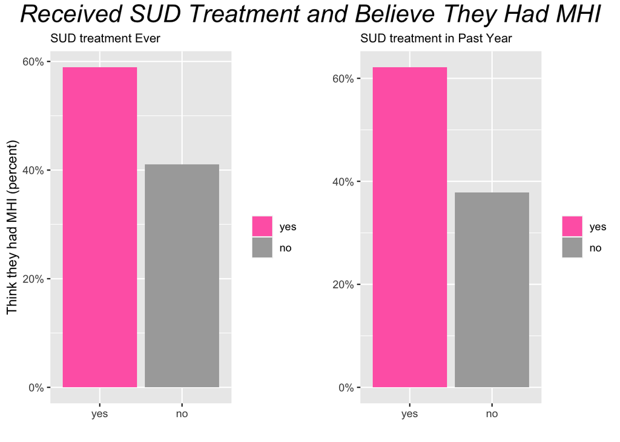

```r
#Respondents who ever received treatment and think they had MH issues in the past year
  ever <- clean_NSDUH %>%
    filter(rec_sub_trtm == "yes") %>%
    filter(!is.na(think_had_mh)) %>%
    ggplot(aes(x = think_had_mh, y = after_stat(count/sum(count)), fill = think_had_mh)) +
    geom_bar() +
    theme(plot.title = element_text(size= 10)) +
    scale_y_continuous(labels = percent) +
    ggtitle("SUD treatment Ever") +
    xlab(" ") +
    ylab("Think they had MHI (percent)") +
    scale_fill_manual(name=" ",values=c("hotpink","darkgrey"))

#Respondents who received treatment in the past year and think they had MH issues in the past year
  pastyear <- clean_NSDUH %>%
    filter(sub_trtm_12mo == "yes") %>%
    filter(!is.na(think_had_mh)) %>%
    ggplot(aes(x = think_had_mh, y = after_stat(count/sum(count)), fill = think_had_mh)) +
    geom_bar() +
    theme(plot.title = element_text(size= 10)) +
    scale_y_continuous(labels = percent) +
    ggtitle("SUD treatment in Past Year") +
    xlab(" ") +
    ylab(" ") +
    scale_fill_manual(name=" ",values=c("hotpink","darkgrey"))

  grid.arrange(ever, pastyear, nrow = 1, top = textGrob("Received SUD Treatment and Believe They Had MHI",gp=gpar(fontsize=20,font=3)))
```

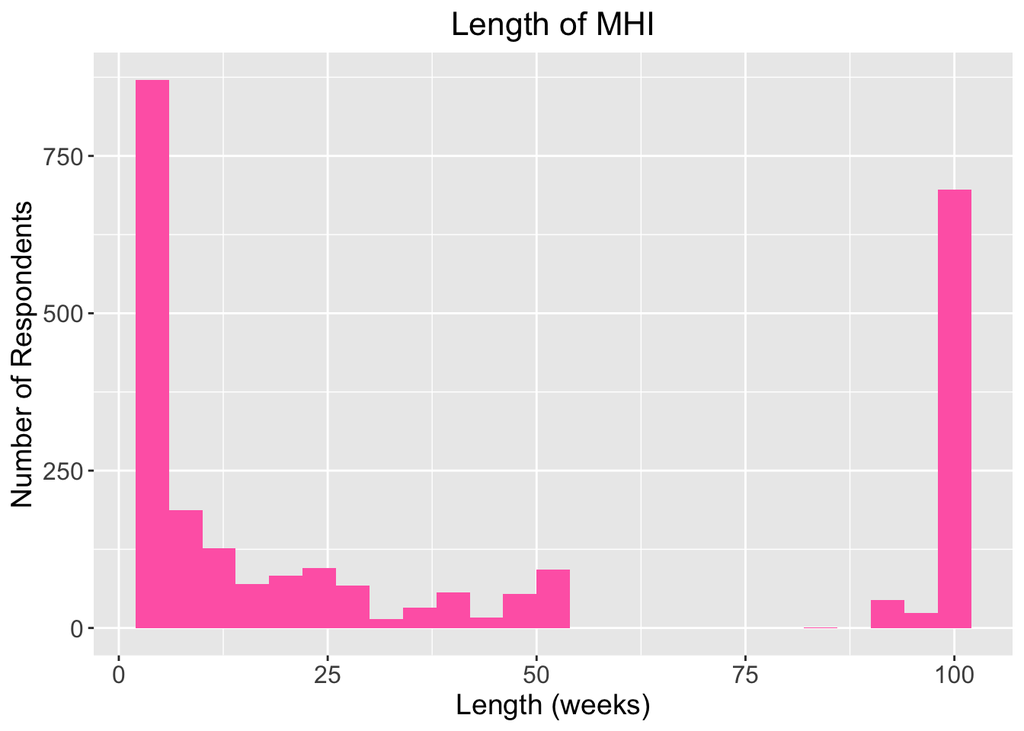

```r
#Number of weeks of MHI
  clean_NSDUH %>%
    filter(rec_sub_trtm == "yes") %>%
    filter(num_weeks_mh >= 2) %>%
    ggplot(aes(x = num_weeks_mh)) +
    geom_histogram(fill = "hotpink", binwidth = 4) +
    plot_theme() +
    ggtitle("Length of MHI") +
    xlab("Length (weeks)") +
    ylab("Number of Respondents")
```

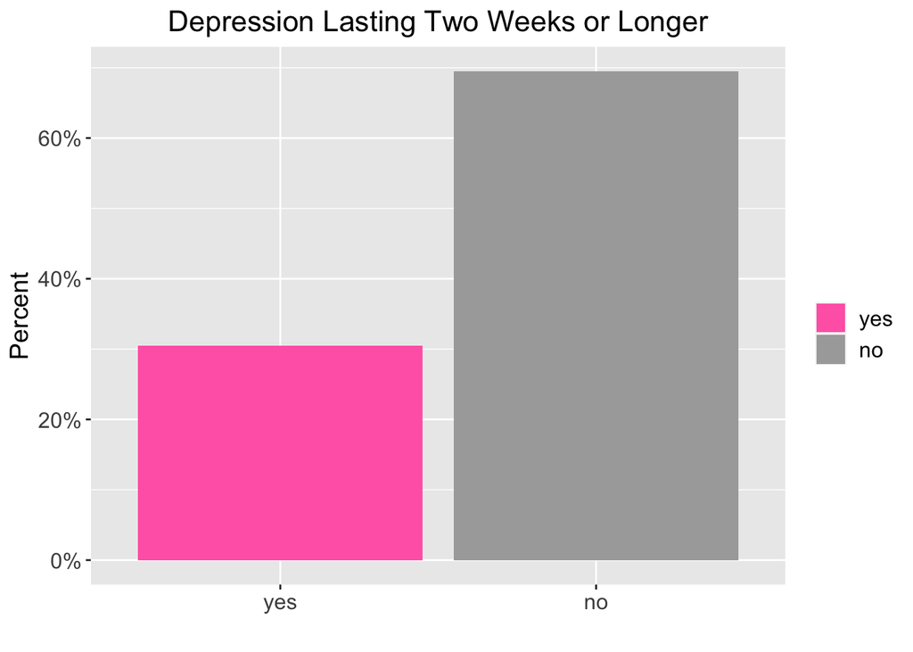

```r
#Respondents who had depression lasting two weeks or longer
  clean_NSDUH %>%
    filter(rec_sub_trtm == "yes") %>%
    filter(!is.na(dep_two_weeks)) %>%
    ggplot(aes(x = dep_two_weeks, y = after_stat(count/sum(count)), fill = dep_two_weeks)) +
    geom_bar() +
    plot_theme() +
    scale_y_continuous(labels = percent) +
    ggtitle("Depression Lasting Two Weeks or Longer") +
    xlab(" ") +
    ylab("Percent") +
    scale_fill_manual(name=" ",values=c("hotpink","darkgrey"))
```

**Recovery rates of SUD and MHI**

Recovery rates of respondents who received SUD treatment and think they had MHI were analyzed. Around 65 percent believe they are recovered from MHI while close to 80 percent believe they are recovered from SUD. This may indicate the need for more mental health resources to be available, especially within SUD treatment programs.

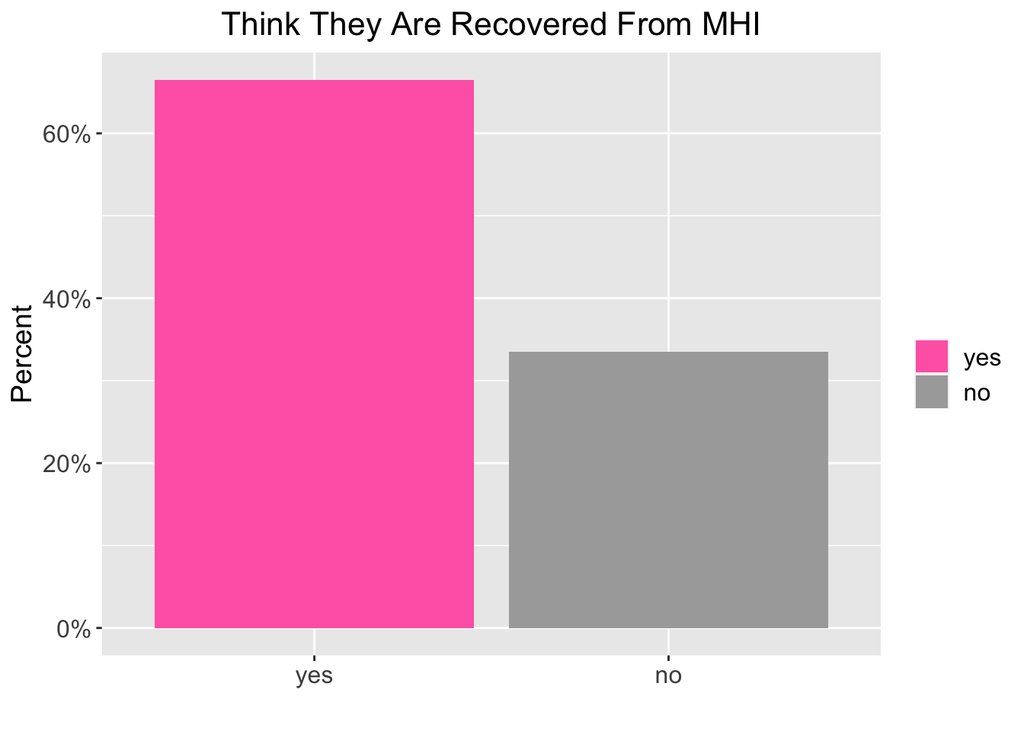

```r
 #Respondents who believe they had SUD who think they are recovered
  clean_NSDUH %>%
    filter(rec_sub_trtm == "yes" & think_had_mh == "yes") %>%
    filter(!is.na(think_recovered_mh)) %>%
    ggplot(aes(x = think_recovered_mh, y = after_stat(count/sum(count)), fill = think_recovered_mh)) +
    geom_bar() +
    plot_theme() +
    scale_y_continuous(labels = percent) +
    ggtitle("Think They Are Recovered From MHI") +
    xlab(" ") +
    ylab("Percent") +
    scale_fill_manual(name=" ",values=c("hotpink","darkgrey"))
```

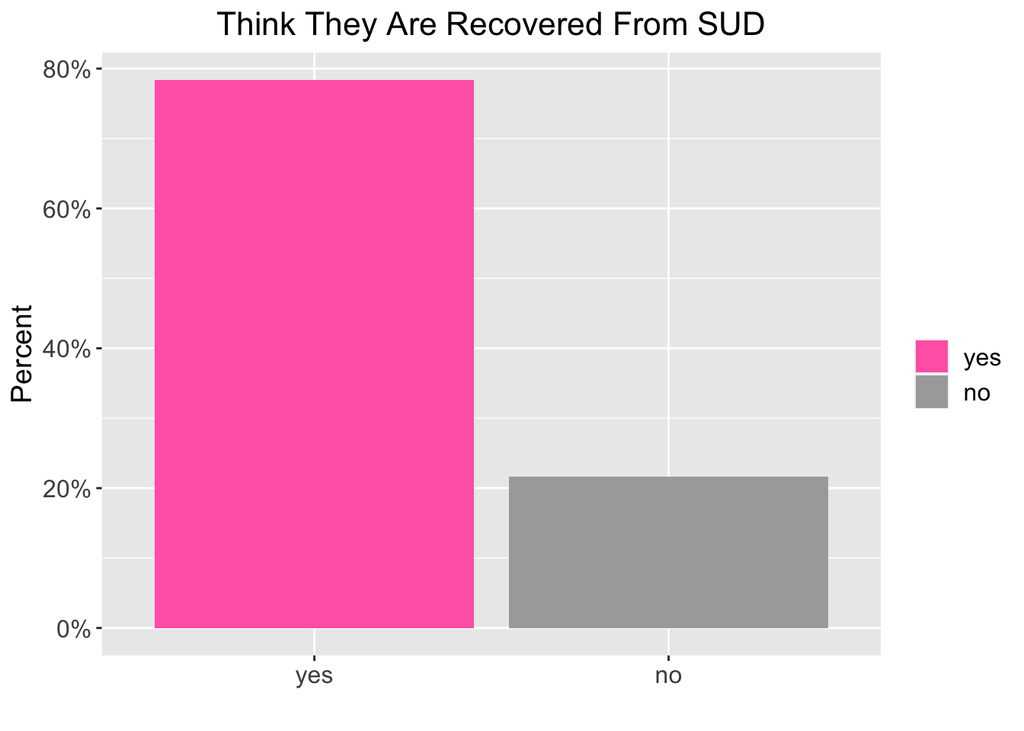

```r
#Respondents who believe they had MHI who think they are recovered
  clean_NSDUH %>%
    filter(rec_sub_trtm == "yes" & think_had_mh == "yes") %>%
    filter(!is.na(think_recovered_sub)) %>%
    ggplot(aes(x = think_recovered_sub, y = after_stat(count/sum(count)), fill = think_recovered_sub)) +
    geom_bar() +
    plot_theme() +
    scale_y_continuous(labels = percent) +
    ggtitle("Think They Are Recovered From SUD") +
    xlab(" ") +
    ylab("Percent") +
    scale_fill_manual(name=" ",values=c("hotpink","darkgrey"))
```

## 5 Conclusion

These data give a small look into the MHI and SUD rates among adults in the US. Future directions in this project could include looking into the disparity between MHI and SUD recovery rates. However, there are limitations to this study. While the NSDUH can provide valuable information it does have some limitations. It is a survey based on self-reporting which leaves the possibility of respondents altering responses in one way or another.